# Monte Carlo and Bootsrap

Sasha Bakker

11/7/2020

```r
suppressMessages(library(tidyverse))
```

# Part I - Monte Carlo

## Problem 1a

Compute the following integral using Monte Carlo integration (provide estimate and estimated standard error):

$$\int_0^2 \frac{\cos(x(2-x))}{1+x+\sqrt{x}}dx$$

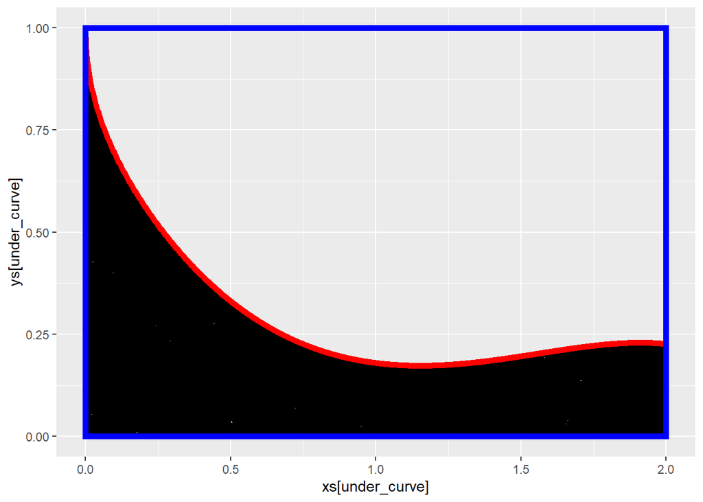

```r
xmin <- 0
xmax <- 2

ymin <- 0
ymax <- 1

integrand <- function(x){

  top <- cos(x*(2-x))
  bottom <- 1 + x + sqrt(x)
  return(top / bottom)

}

S <- 100000

xs <- runif(S, min = xmin, max = xmax)
ys <- runif(S, min = ymin, max = ymax)
under_curve <- (ys <= integrand(xs))

x <- seq(xmin, xmax, length.out = 1000)
y <- integrand(x)


ggplot() +
  geom_point(aes(x=xs[under_curve], y=ys[under_curve])) +
  geom_line(aes(x=x, y=y), col="red", size=2) +
    geom_rect(aes(xmin = xmin, xmax = xmax, ymin = ymin, ymax = ymax), color = "blue", alpha=0, size = 2)
```

```r
fraction_area <- sum(under_curve)/S
fraction_area
```

```
## [1] 0.29505
```

- The estimate of the ratio between the area under the red curve and the area of the blue rectangle is approximately 0.29.
- We know the area of the blue rectangle is 2. Thus we compute the estimate of the area under the red curve as follows

```r
curve_area = 2*fraction_area
curve_area
```

```
## [1] 0.5901
```

- This area signifies an estimate of the integral.
- Let’s compute the mean and standard error of the integral for a series to get a more precise estimate of the integral

```r
MC_fraction <- function(integrand, S){

  xs <- runif(S, min = xmin, max = xmax)
  ys <- runif(S, min = ymin, max = ymax)
  under_curve <- (ys <= integrand(xs))

  return(sum(under_curve)/S)

}


S <- 10000
N <- 10000
areas_seq <- c()

for (val in 1:N){
  area <- 2*MC_fraction(integrand, S)
  areas_seq <- c(areas_seq, area)
}

mc_estimate <- mean(areas_seq)
mc_se <- sd(areas_seq) / sqrt(length(areas_seq))

paste("The estimate is:", mc_estimate)
```

```
## [1] "The estimate is: 0.59076656"
```

```r
paste("The error is:", mc_se)
```

```
## [1] "The error is: 9.09432704738753e-05"
```

## Problem 1b

Compare your estimate to quadrature integration using `integrate()`

```r
integrate(integrand, xmin, xmax)
```

```
## 0.5907916 with absolute error < 7.9e-05
```

## Problem 2

Estimate the power of the Student’s $t$-test for difference in means for two normally distributed populations.

The Student’s $t$-test is a standard test for difference in means between two normal populations. In this exercise, we will estimate the power of $t$-test using Monte Carlo estimators.

Assume two normal populations with a difference in means of `diff_mean`. The first sample with `n1 = 30` observations, `mean = mean1`, `sd = sd1` and the second sample with `n2 = 20` observations, `sd = sd2` and `mean = mean1 + diff_mean`.

## Problem 2a

Write a function that returns a data frame of 50(`= n1 + n2`) rows, where the first column is named `smpl` and contains the normal draws from both populations, add a second column named `pop` indicates which population an observation came from (taking values of 1 or 2). The inputs for this function should be `n1`, `mean1`, `sd1`, `n2`, `sd2` and `true_diff`.

```r
n1 <- 30; mean1 <- 0; sd1 <- 1
n2 <- 20; sd2 <- 1.5
true_diff <- 0.5

return_df <- function(n1, mean1, sd1, n2, sd2, true_diff){

  # Initialize empty data frame
  df <- data.frame(matrix(ncol = 2, nrow = n1 + n2))
  colnames(df) <- c("smpl", "pop")

  # Draw from normal distributions
  sample1 <- rnorm(n1, mean1, sd1)
  sample2 <- rnorm(n2, mean1 + true_diff, sd2)

  # Assign the normal draws to the data frame
  df$smpl[1:n1] <- sample1
  df$smpl[(1+n1):(n1+n2)] <- sample2

  # Assign the population indicator to the data frame
  df$pop[1:n1] <- replicate(n1,1)
  df$pop[(1+n1):(n1+n2)] <- replicate(n2, 2)

  # Return the data frame
  return(df)
}

df <- return_df(n1, mean1, sd1, n2, sd2, true_diff)
head(df, 6)
```

```
##         smpl pop
## 1  1.6468052   1
## 2 -1.8520940   1
## 3  2.2816039   1
## 4  0.8263027   1
## 5  0.8471339   1
## 6  0.7220557   1
```

## Problem 2b

The hypotheses we want to test by this simulation study is:

$$H_0: \text{mean}_1 - \text{mean}_2 = 0$$
$$H_a: \text{mean}_1 - \text{mean}_2 \neq 0$$

at level $\alpha$ (let us fix `alpha = 0.05` for the rest of the exercise)

We can use a standard `t`-test for that:

```r
alpha <- 0.05
t_test_result <-
  t.test(
    x = df$smpl[df$pop == 1],
    y = df$smpl[df$pop == 2],
    conf.level = 1 - alpha
  )
```

The decision rule is to reject if:

```r
t_test_result$p.value < alpha
```

```
## [1] FALSE
```

Write a function that performs this $t$-test for an input data frame that is define in the same way as ours (a `smpl` column for sample, a `pop` column for population (taking values of 1 or 2)). A second input `alpha` should be the level of the test.

The function’s output should be a logical value - whether or not the null is rejected.

```r
run_t_test <- function(df, alpha){

  t_test_result <-
  t.test(
    x = df$smpl[df$pop == 1],
    y = df$smpl[df$pop == 2],
    conf.level = 1 - alpha
  )
  return(t_test_result$p.value < alpha)
}

run_t_test(df, alpha)
```

```
## [1] FALSE
```

- The decision rule to reject the null hypothesis in favor of the alternative hypothesis is if the p-value is less than alpha.
- In this problem, the function returns `FALSE` which means the p-value is greater than or equal to alpha, signifying that we fail to reject the null hypothesis in favor of the alternative hypothesis.

## Problem 2c

Write a function that estimates the power of the $t$-test for these parameters and this difference in means. That is, the function should take as inputs `S`, the number of tests to perform (which in this case is the number of Monte Carlo samples), and the parameters `n1`, `mean1`, `sd`, `n2`, `sd2`, `true_diff`, and `alpha`.

The function will generate `S` different data frames simulated from the same set of parameters (`S = 500` is a reasonable size, but you may increase it for better accuracy). It will test each of those using the `t-test` and measure the rejection rate for the test. This rate is an estimate of the power for this set of parameters. The function will return a vector so that each of its elements is a power estimate.

```r
power_estimate <- function(S, N, n1, mean1, sd1, n2, sd2, true_diff, alpha){

  powers <-  c()

  for (i in 1:N){

    boo <- c()

    for (j in 1:S){

      df <- return_df(n1, mean1, sd1, n2, sd2, true_diff)
      boo <- c(boo, run_t_test(df, alpha))
    }

    # Rejection of null represented by TRUE
    n_true <- sum(as.integer(boo))
    power <- n_true/S

    powers <- c(powers, power)
  }

  return(powers)
}

S <- 2000
N <- 50

powers <- power_estimate(S, N, n1, mean1, sd1, n2, sd2, true_diff, alpha)

mean(powers)
```

```
## [1] 0.24596
```

```r
sd(powers)/N
```

```
## [1] 0.0001813199
```

- The mean rejection rate is approximately 25%

More power signifies that we have a better test that is better able to identify a difference between the normal means when it is actually there. However, it is also important to verify that our test does not reject the null more than it should (type_I error should be less than or equal to `alpha`). If that happens, the rejections in other cases cannot be considered reliable.

```r
powers_typeI <- power_estimate(S, N, n1, mean1, sd1, n2, sd2, 0, alpha)

mean(powers_typeI)
```

```
## [1] 0.0503
```

```r
sd(powers_typeI)/N
```

```
## [1] 9.491134e-05
```

## Problem 2d

**Power Study**: we will now extend the above to a full blown “power study”. That is, we check the power of the test for different levels of true difference in means (take a following sequence: `seq(-2, 2, 0.2)` to be the domain of true difference values). For each level of true difference in means, record the estimated power and conclude by plotting the estimated power vs. the true difference in means.

```r
S <- 1000
N <- 20
diff_means <- seq(-2, 2, 0.2)

mean_powers <- c()
errors <- c()

for (true_diff in diff_means){

  powers_temp <- power_estimate(S, N, n1, mean1, sd1, n2, sd2, true_diff, alpha)

  mean_powers <- c(mean_powers, mean(powers_temp))
  errors <-  c(errors, sd(powers_temp)/N)
}
```

The results satisfy what we expect:

1. As the absolute value of the true difference in means grows, a good test will have more power (rejection rate closer to 1).
2. Since the $t$-test and the normal distributions are symmetric, we expect the power curve to be symmetric around 0.
3. Where the difference in means is 0, the power should be below or at `alpha`.

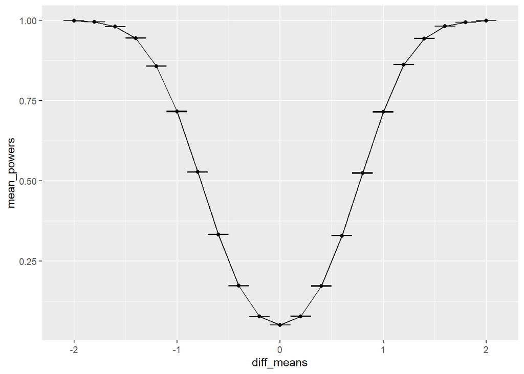

```r
ggplot() +
  geom_point(aes(x=diff_means, y=mean_powers)) +
  geom_errorbar(aes(x=diff_means, y=mean_powers, ymin = mean_powers - errors, ymax = mean_powers + errors), width = 0.2, position = position_dodge(0.05)) +
  geom_line(aes(x=diff_means, y=mean_powers))
```

```r
print(min(mean_powers))
```

```
## [1] 0.0516
```

# Part II - Bootstrap

Estimate standard error of robust psi regression estimators.

In lecture 8 we developed a “robust” regression based on fitting the `psi` function. In the lecture, we fitted the parameters using our gradient descent method. In the interest of time, fit the parameters here using `optim`.

```r
library(numDeriv)
x <- seq(-5,5,0.01)

psi <- function(x, c) {
  return (
    ifelse(
      abs(x) > c,
      2 * c * abs(x) - c^2,
      x^2
    )
  )
}

fit1 <- optimize(psi, c(-5,5), c = 1.2)
fit1
```

```
## $minimum
## [1] 4.440892e-16
##
## $objective
## [1] 1.972152e-31
```

```r
#fit2 <- optim(par = 1, fn = psi, x=x, method="Brent", lower = 0, upper = 1)
#fit2
```

The optimization procedure provides us with point estimates, but we have no measure of uncertainty for them: neither a standard deviation nor confidence intervals to determine whether or not they are different from 0 with any statistical certainty. The bootstrap method allows us to do so.

Use the same data and regression model as before, data being `MASS::cats` and mdoel being `Hwt` (heart weight) as response and `Bwt` (body weight) as the single predictor.

## Problem 1a

Estimate the coefficients of a simple linear regression where the fitting is based on minimizing the mean of the psi-error.

```r
cats <- MASS::cats
c <- 1

mean_psi_regression <- function(data, par) {

  X <- data$Bwt
  Y <- data$Hwt
  return( mean ( psi(Y-(par[1]+par[2]*X), c) ) )

}

# Compute initial guesses
b0_i <- coef(lm(Hwt ~ Bwt, data = MASS::cats))["(Intercept)"]
b1_i <- coef(lm(Hwt ~ Bwt, data = MASS::cats))["Bwt"]

result <- optim(par = c(b0_i, b1_i), fn = mean_psi_regression, data = cats)

b0 <- result$par["(Intercept)"]
b1 <- result$par["Bwt"]

cat(paste("b0 = ", b0, ", b1 = ", b1, ", c = ", c, sep=""))
```

```
## b0 = -0.142182314168739, b1 = 3.91029029507439, c = 1
```

## Problem 1b

Construct a bootstrap sample for the estimated coefficients of a simple linear regression where the fitting is based on minimizing the mean of the psi-error.

```r
n <- nrow(cats)
M <- 10000 # number of draws

# sample for estimated regression coefficients
est_coeffs_bstp_sample <- data.frame(b0 = numeric(M), b1 = numeric(M))

for (m in 1:M){

  # sample indices with replacement
  bootstrap_sample_idx <- sample(n, replace = TRUE)

  # bootstrap sample
  bstp <- cats[bootstrap_sample_idx, ]

  coeffs <- optim(par = c(b0_i, b1_i), fn = mean_psi_regression, data = bstp)

  est_coeffs_bstp_sample[m,1] <- coeffs$par["(Intercept)"]
  est_coeffs_bstp_sample[m,2] <- coeffs$par["Bwt"]

}

head(est_coeffs_bstp_sample, 6)
```

```
##           b0       b1
## 1  0.9535093 3.541712
## 2 -0.3523900 4.008991
## 3 -0.1231361 3.987214
## 4 -1.3032893 4.302527
## 5 -0.3777716 3.943214
## 6 -0.6306157 4.057321
```

## Problem 1c

Estimate the standard deviations of each of the coefficients

```r
sd_b0 <- sd(est_coeffs_bstp_sample$b0)
sd_b1 <- sd(est_coeffs_bstp_sample$b1)

cat(paste("sd_b0 = ", sd_b0, ", sd_b1 = ", sd_b1, sep = ""))
```

```
## sd_b0 = 0.826385041305366, sd_b1 = 0.314806899831392
```

## Problem 1d

Construct 95% confidence intervals for the coefficients and, based on those, determine whether or not we can reject a null hypothesis that each of them is equal to zero.

```r
alpha <- 0.05

# CI for b0
(bootstrap_CI <- quantile(est_coeffs_bstp_sample$b0, c(alpha/2, 1 - alpha/2)))
```

```
##      2.5%     97.5%
## -1.800947  1.482706
```

```r
# CI for b1
(bootstrap_CI <- quantile(est_coeffs_bstp_sample$b1, c(alpha/2, 1 - alpha/2)))
```

```
##     2.5%    97.5%
## 3.306057 4.559379
```

- Because zero is in the confidence interval for b0, we fail to reject the null that b0 = 0 at 95% confidence.
- Because zero is not in the confidence interval for b1, we reject the null that b1 = 0 at 95% confidence.